# LAB 6 - CNN

**NAME(S):** Marione Ogboi, Erika Puente Lopez

**Data Citation:** https://www.kaggle.com/datasets/preetviradiya/brian-tumor-dataset/data

```python
!pip install nbconvert

 from google.colab import drive
 drive.mount('/content/drive')
!jupyter nbconvert --to html ""
```

```python
!pip install -q pandas
!pip install -q numpy
!pip install -q matplotlib
!pip install -q seaborn
!pip install scikeras
!pip install tensorflow

import seaborn as sns
import matplotlib.pyplot as plt
import numpy as np
import pandas as pd
from sklearn.preprocessing import LabelEncoder
from sklearn.model_selection import train_test_split
```

```python
import zipfile
import os
import glob
from PIL import Image
from sklearn.preprocessing import LabelEncoder
from tensorflow.keras.preprocessing.image import img_to_array

file_path = '/content/Brain Tumor Data Set.zip'
output_dir = 'Brain Tumor Data Set'

with zipfile.ZipFile(file_path, 'r') as zip_ref:
  zip_ref.extractall(output_dir)

parent_folder = os.path.join(output_dir, 'Brain Tumor Data Set')

if not os.path.exists(parent_folder):
  print(f"Path does not exist: {parent_folder}")

else:
  image_files=[]
  labels =[]


  for root, _, files in os.walk(parent_folder):
    for file in files:
      if file.lower().endswith(('.png', '.jpg', '.jpeg')):
        image_files.append(os.path.join(root, file))

        label = os.path.basename(root)
        labels.append(label)

  if not image_files:
    print("No image files found in the subfolders.")
  else:
    print(f"Number of image files: {len(image_files)}")

    image_arrays=[]
    for file in image_files:
      try:
        image = Image.open(file)
        image = image.convert('RGB')
        image = image.resize((64, 64))  # Resize the image to a fixed size (64x64)
        image = img_to_array(image)
        image_arrays.append(image)
      except Exception as e:
        print(f"Error")

    X = np.array(image_arrays)

    label_encoder = LabelEncoder()
    y_encoded = label_encoder.fit_transform(labels)

    X = X.astype('float32') / 255.0

    print(X.shape)
```

```
Number of image files: 4514
(4514, 64, 64, 3)
```

## Evaluation Metrics?

For our evaluation metric, we will be using **Recall.** Recall will measure the proportions of actual positive cases correctly identified by the model. Since we're dealing with cancer and determining if a person has a tumor or not, a false negative could have severe consequences in the real world. It's important to minimize the amount of false negatives the model predicts as much as possible to ensure treatment can be delivered on time, especially something as time sensitive as cancer.

## Method For Dividing Data?

The dataset itself is closer to balanced for the most part, with 55% of the images being cancerous and 45% being normal. **Shuffle-Split Method** without stratification seems to be the most appropriate, as is much less computationally expensive and can reliabily generalize the data for us. With the data already being rather balanced, k-folds do not seem to be necessary/ bring additional benefits.

```python
import tensorflow as tf
import numpy as np
from sklearn.model_selection import train_test_split
from sklearn.preprocessing import LabelEncoder
from sklearn.metrics import recall_score

tf.random.set_seed(2)
np.random.seed(0)

# Normalize the dataset
X = X.astype(np.float32) / 16.0 - 0.5


X = X.reshape((X.shape[0], 64, 64, 3))

data_augmentation = tf.keras.Sequential([
    tf.keras.layers.RandomFlip("horizontal"),
    tf.keras.layers.RandomRotation(0.1),
    tf.keras.layers.RandomZoom(0.2),
])


# Split the dataset using Shuffle Split
X_train, X_test, y_train, y_test = train_test_split(
    X, y_encoded, test_size=0.2, random_state=42
)

# Define a simple CNN model
model = tf.keras.Sequential([
    tf.keras.layers.InputLayer(input_shape=(64, 64, 3)),  # Define the input shape here
    data_augmentation,  # Apply data augmentation here
    tf.keras.layers.Conv2D(32, (3, 3), activation='relu'),
    tf.keras.layers.MaxPooling2D((2, 2)),
    tf.keras.layers.Flatten(),
    tf.keras.layers.Dense(128, activation='relu'),
    tf.keras.layers.Dense(len(np.unique(y_encoded)), activation='softmax')
])

# Compile the model
model.compile(optimizer='adam',
              loss='sparse_categorical_crossentropy',
              metrics=['accuracy'])  # Accuracy is tracked during training but not used for evaluation

# Train the model with a validation split
model.fit(X_train, y_train, epochs=10, batch_size=32, validation_split=0.2)

# Evaluate the model
y_pred = model.predict(X_test)
y_pred_classes = y_pred.argmax(axis=1)  # Predicted class indices

# Calculate Recall
recall = recall_score(y_test, y_pred_classes, average='weighted')  # Weighted Recall
print(f"Recall: {recall:.2f}")
```

```
91/91 ━━━━━━━━━━━━━━━━━━━━ 5s 24ms/step - accuracy: 0.5068 - loss: 0.8613 - val_accuracy: 0.5422 - val_loss: 0.6897
91/91 ━━━━━━━━━━━━━━━━━━━━ 2s 15ms/step - accuracy: 0.5413 - loss: 0.6906 - val_accuracy: 0.5422 - val_loss: 0.6896
91/91 ━━━━━━━━━━━━━━━━━━━━ 1s 16ms/step - accuracy: 0.5413 - loss: 0.6903 - val_accuracy: 0.5422 - val_loss: 0.6895
91/91 ━━━━━━━━━━━━━━━━━━━━ 2s 17ms/step - accuracy: 0.5356 - loss: 0.6912 - val_accuracy: 0.5422 - val_loss: 0.6895
91/91 ━━━━━━━━━━━━━━━━━━━━ 1s 14ms/step - accuracy: 0.5413 - loss: 0.6900 - val_accuracy: 0.5422 - val_loss: 0.6894
91/91 ━━━━━━━━━━━━━━━━━━━━ 1s 13ms/step - accuracy: 0.5413 - loss: 0.6899 - val_accuracy: 0.5422 - val_loss: 0.6893
91/91 ━━━━━━━━━━━━━━━━━━━━ 4s 26ms/step - accuracy: 0.5413 - loss: 0.6898 - val_accuracy: 0.5422 - val_loss: 0.6893
91/91 ━━━━━━━━━━━━━━━━━━━━ 2s 22ms/step - accuracy: 0.5413 - loss: 0.6898 - val_accuracy: 0.5422 - val_loss: 0.6891
91/91 ━━━━━━━━━━━━━━━━━━━━ 2s 16ms/step - accuracy: 0.5413 - loss: 0.6898 - val_accuracy: 0.5422 - val_loss: 0.6890
91/91 ━━━━━━━━━━━━━━━━━━━━ 1s 14ms/step - accuracy: 0.5413 - loss: 0.6897 - val_accuracy: 0.5422 - val_loss: 0.6889
29/29 ━━━━━━━━━━━━━━━━━━━━ 0s 5ms/step
Recall: 0.53
```

## Data Augmentation?

In preprocessing, we used flipping the image, adding angular variations, and different image scaling. The multiple angles and orientations of each image can help the model detect common patterns in patients with cancer and patients who do not have cancer.

```python
import tensorflow.keras as keras
from tensorflow.keras.models import Sequential
from tensorflow.keras.layers import Reshape
from tensorflow.keras.layers import Dense, Dropout, Activation, Flatten
from tensorflow.keras.layers import Conv2D, MaxPooling2D
from tensorflow.keras.utils import plot_model
from tensorflow.keras.preprocessing.image import ImageDataGenerator

keras.__version__
```

```
'3.5.0'
```

```python
NUM_CLASSES = 2
print(X_train.shape)
print(X_test.shape)
```

```
(3611, 64, 64, 3)
(903, 64, 64, 3)
```

```python
%%time

from sklearn.metrics import roc_curve, auc

#creating a baseline mlp with 5 layers

y_train_one = keras.utils.to_categorical(y_train, NUM_CLASSES)
y_test_one = keras.utils.to_categorical(y_test, NUM_CLASSES)

#make a 5 layer keras MLP
mlp = Sequential()
mlp.add( Flatten(input_shape= (64, 64, 3)) )
mlp.add(Dense( units=30,
               activation= 'relu'))
mlp.add( Dense(units = 30, activation = 'relu'))
mlp.add( Dense(units =20, activation = 'relu'))
mlp.add( Dense(units= 15, activation = 'relu'))
mlp.add( Dense(NUM_CLASSES))

mlp.add( Activation('softmax'))

mlp.compile(loss='mean_squared_error',
            optimizer= 'rmsprop',
            metrics=['accuracy'])

mlp.fit(X_train, y_train_one,
        batch_size= 32, epochs=150,
        shuffle= True, verbose=0)

y_pred = mlp.predict(X_test)
y_pred_classes = y_pred.argmax(axis=1)  # Predicted class indices

# Calculate Recall
recall = recall_score(y_test, y_pred_classes, average='weighted')  # Weighted Recall
print(f"Recall: {recall:.2f}")
```

```
29/29 ━━━━━━━━━━━━━━━━━━━━ 0s 7ms/step
Recall: 0.53
CPU times: user 47.7 s, sys: 3.62 s, total: 51.3 s
Wall time: 49.8 s
```

```python
#create a cnn with three convolutional layers and one output layer

#make a CNN with conv layer and max pooling

cnn = Sequential()

#First layer
cnn.add( Conv2D(filters=16, kernel_size= (5,5), padding= 'same',
                input_shape=(64,64,3),
                ))
cnn.add( MaxPooling2D(pool_size= (2,2)))
cnn.add(Activation('relu'))
cnn.add(Dropout(0.25))

#Output layer
cnn.add(Flatten())
cnn.add(Dense(NUM_CLASSES))
cnn.add(Activation('softmax'))

print(cnn.summary())

plot_model(
    cnn, to_file= 'model.png', show_shapes=True, show_layer_names=True,
    rankdir= 'LR', expand_nested= False, dpi=96
)
```

```
Model: "sequential_14"
```

```
┏━━━━━━━━━━━━━━━━━━━━━━━━━━━━━━━━━━━━━━┳━━━━━━━━━━━━━━━━━━━━━━━━━━━━━┳━━━━━━━━━━━━━━━━━┓
┃ Layer (type)                         ┃ Output Shape                ┃         Param # ┃
┡━━━━━━━━━━━━━━━━━━━━━━━━━━━━━━━━━━━━━━╇━━━━━━━━━━━━━━━━━━━━━━━━━━━━━╇━━━━━━━━━━━━━━━━━┩
│ conv2d_10 (Conv2D)                   │ (None, 64, 64, 16)          │           1,216 │
├──────────────────────────────────────┼─────────────────────────────┼─────────────────┤
│ max_pooling2d_10 (MaxPooling2D)      │ (None, 32, 32, 16)          │               0 │
├──────────────────────────────────────┼─────────────────────────────┼─────────────────┤
│ activation_18 (Activation)           │ (None, 32, 32, 16)          │               0 │
├──────────────────────────────────────┼─────────────────────────────┼─────────────────┤
│ dropout_2 (Dropout)                  │ (None, 32, 32, 16)          │               0 │
├──────────────────────────────────────┼─────────────────────────────┼─────────────────┤
│ flatten_12 (Flatten)                 │ (None, 16384)               │               0 │
├──────────────────────────────────────┼─────────────────────────────┼─────────────────┤
│ dense_24 (Dense)                     │ (None, 2)                   │          32,770 │
├──────────────────────────────────────┼─────────────────────────────┼─────────────────┤
│ activation_19 (Activation)           │ (None, 2)                   │               0 │
└──────────────────────────────────────┴─────────────────────────────┴─────────────────┘
```

```
 Total params: 33,986 (132.76 KB)
```

```
 Trainable params: 33,986 (132.76 KB)
```

```
 Non-trainable params: 0 (0.00 B)
```

```
None
```

[figure not shown]

```python
%%time
print(X_train.shape)
from sklearn.model_selection import ShuffleSplit
from sklearn.metrics import recall_score
from tensorflow.keras.models import Sequential
from tensorflow.keras.layers import Conv2D, MaxPooling2D, Activation, Flatten, Dense
from tensorflow.keras.utils import plot_model
import numpy as np

X = np.random.rand(1000, 64, 64, 3)
y = np.random.randint(0, 2, size=(1000,))  # Binary classification (0 or 1)
NUM_CLASSES = 2

# Initialize CNN
cnn = Sequential()
cnn.add(Conv2D(filters=16, kernel_size=(2, 2), padding='same', input_shape=(64, 64, 3)))
cnn.add(MaxPooling2D(pool_size=(2, 2)))
cnn.add(Activation('relu'))
cnn.add(Flatten())
cnn.add(Dense(NUM_CLASSES))
cnn.add(Activation('softmax'))

# Compile the model
cnn.compile(loss='sparse_categorical_crossentropy',
            optimizer='adam',
            metrics=['accuracy'])

# Print model summary
print(cnn.summary())

# Plot the model architecture
plot_model(
    cnn, to_file='model.png', show_shapes=True, show_layer_names=True,
    rankdir='LR', expand_nested=False, dpi=96
)

# Use ShuffleSplit to split the dataset
ss = ShuffleSplit(n_splits=1, test_size=0.2, random_state=42)

for train_index, test_index in ss.split(X):
    X_train, X_test = X[train_index], X[test_index]
    y_train, y_test = y[train_index], y[test_index]

# Train the CNN
cnn.fit(X_train, y_train, epochs=100, batch_size=32, validation_split=0.2)

# Evaluate on test set
y_pred = cnn.predict(X_test)
y_pred_classes = np.argmax(y_pred, axis=1)  # Get the predicted class indices

# Calculate Recall
recall = recall_score(y_test, y_pred_classes, average='weighted')  # Weighted Recall
print(f"Recall: {recall:.2f}")
```

```
(3611, 64, 64, 3)
```

```
Model: "sequential_15"
```

```
┏━━━━━━━━━━━━━━━━━━━━━━━━━━━━━━━━━━━━━━┳━━━━━━━━━━━━━━━━━━━━━━━━━━━━━┳━━━━━━━━━━━━━━━━━┓
┃ Layer (type)                         ┃ Output Shape                ┃         Param # ┃
┡━━━━━━━━━━━━━━━━━━━━━━━━━━━━━━━━━━━━━━╇━━━━━━━━━━━━━━━━━━━━━━━━━━━━━╇━━━━━━━━━━━━━━━━━┩
│ conv2d_11 (Conv2D)                   │ (None, 64, 64, 16)          │             208 │
├──────────────────────────────────────┼─────────────────────────────┼─────────────────┤
│ max_pooling2d_11 (MaxPooling2D)      │ (None, 32, 32, 16)          │               0 │
├──────────────────────────────────────┼─────────────────────────────┼─────────────────┤
│ activation_20 (Activation)           │ (None, 32, 32, 16)          │               0 │
├──────────────────────────────────────┼─────────────────────────────┼─────────────────┤
│ flatten_13 (Flatten)                 │ (None, 16384)               │               0 │
├──────────────────────────────────────┼─────────────────────────────┼─────────────────┤
│ dense_25 (Dense)                     │ (None, 2)                   │          32,770 │
├──────────────────────────────────────┼─────────────────────────────┼─────────────────┤
│ activation_21 (Activation)           │ (None, 2)                   │               0 │
└──────────────────────────────────────┴─────────────────────────────┴─────────────────┘
```

```
 Total params: 32,978 (128.82 KB)
```

```
 Trainable params: 32,978 (128.82 KB)
```

```
 Non-trainable params: 0 (0.00 B)
```

```
None
20/20 ━━━━━━━━━━━━━━━━━━━━ 2s 36ms/step - accuracy: 0.5004 - loss: 1.0992 - val_accuracy: 0.5312 - val_loss: 0.7502
20/20 ━━━━━━━━━━━━━━━━━━━━ 0s 5ms/step - accuracy: 0.5606 - loss: 0.6959 - val_accuracy: 0.4688 - val_loss: 0.8788
20/20 ━━━━━━━━━━━━━━━━━━━━ 0s 4ms/step - accuracy: 0.5826 - loss: 0.6638 - val_accuracy: 0.4875 - val_loss: 0.7172
20/20 ━━━━━━━━━━━━━━━━━━━━ 0s 5ms/step - accuracy: 0.8145 - loss: 0.5440 - val_accuracy: 0.4750 - val_loss: 0.7706
20/20 ━━━━━━━━━━━━━━━━━━━━ 0s 5ms/step - accuracy: 0.8208 - loss: 0.4908 - val_accuracy: 0.4688 - val_loss: 0.7934
20/20 ━━━━━━━━━━━━━━━━━━━━ 0s 4ms/step - accuracy: 0.9042 - loss: 0.4168 - val_accuracy: 0.4563 - val_loss: 0.7748
20/20 ━━━━━━━━━━━━━━━━━━━━ 0s 4ms/step - accuracy: 0.9816 - loss: 0.3420 - val_accuracy: 0.4812 - val_loss: 0.7845
20/20 ━━━━━━━━━━━━━━━━━━━━ 0s 5ms/step - accuracy: 0.9953 - loss: 0.2815 - val_accuracy: 0.4688 - val_loss: 0.8077
20/20 ━━━━━━━━━━━━━━━━━━━━ 0s 4ms/step - accuracy: 0.9980 - loss: 0.2391 - val_accuracy: 0.4625 - val_loss: 0.8263
20/20 ━━━━━━━━━━━━━━━━━━━━ 0s 5ms/step - accuracy: 0.9959 - loss: 0.2178 - val_accuracy: 0.5375 - val_loss: 0.7260
20/20 ━━━━━━━━━━━━━━━━━━━━ 0s 4ms/step - accuracy: 0.9674 - loss: 0.2159 - val_accuracy: 0.4563 - val_loss: 0.7573
20/20 ━━━━━━━━━━━━━━━━━━━━ 0s 5ms/step - accuracy: 0.9971 - loss: 0.1573 - val_accuracy: 0.4750 - val_loss: 0.9763
20/20 ━━━━━━━━━━━━━━━━━━━━ 0s 5ms/step - accuracy: 0.9709 - loss: 0.1967 - val_accuracy: 0.4750 - val_loss: 0.8172
20/20 ━━━━━━━━━━━━━━━━━━━━ 0s 5ms/step - accuracy: 0.8588 - loss: 0.2713 - val_accuracy: 0.5500 - val_loss: 0.7761
20/20 ━━━━━━━━━━━━━━━━━━━━ 0s 5ms/step - accuracy: 0.9660 - loss: 0.2133 - val_accuracy: 0.5250 - val_loss: 0.7267
20/20 ━━━━━━━━━━━━━━━━━━━━ 0s 4ms/step - accuracy: 1.0000 - loss: 0.1192 - val_accuracy: 0.5437 - val_loss: 0.7942
20/20 ━━━━━━━━━━━━━━━━━━━━ 0s 4ms/step - accuracy: 1.0000 - loss: 0.1087 - val_accuracy: 0.5375 - val_loss: 0.8237
20/20 ━━━━━━━━━━━━━━━━━━━━ 0s 5ms/step - accuracy: 1.0000 - loss: 0.0944 - val_accuracy: 0.5562 - val_loss: 0.7938
20/20 ━━━━━━━━━━━━━━━━━━━━ 0s 5ms/step - accuracy: 1.0000 - loss: 0.0729 - val_accuracy: 0.5188 - val_loss: 0.7744
20/20 ━━━━━━━━━━━━━━━━━━━━ 0s 5ms/step - accuracy: 1.0000 - loss: 0.0569 - val_accuracy: 0.5250 - val_loss: 0.7848
20/20 ━━━━━━━━━━━━━━━━━━━━ 0s 5ms/step - accuracy: 1.0000 - loss: 0.0501 - val_accuracy: 0.5250 - val_loss: 0.7951
20/20 ━━━━━━━━━━━━━━━━━━━━ 0s 4ms/step - accuracy: 1.0000 - loss: 0.0450 - val_accuracy: 0.5312 - val_loss: 0.8015
20/20 ━━━━━━━━━━━━━━━━━━━━ 0s 5ms/step - accuracy: 1.0000 - loss: 0.0402 - val_accuracy: 0.5250 - val_loss: 0.8070
20/20 ━━━━━━━━━━━━━━━━━━━━ 0s 4ms/step - accuracy: 1.0000 - loss: 0.0361 - val_accuracy: 0.5312 - val_loss: 0.8133
20/20 ━━━━━━━━━━━━━━━━━━━━ 0s 4ms/step - accuracy: 1.0000 - loss: 0.0327 - val_accuracy: 0.4938 - val_loss: 0.8203
20/20 ━━━━━━━━━━━━━━━━━━━━ 0s 6ms/step - accuracy: 1.0000 - loss: 0.0299 - val_accuracy: 0.4938 - val_loss: 0.8275
20/20 ━━━━━━━━━━━━━━━━━━━━ 0s 6ms/step - accuracy: 1.0000 - loss: 0.0276 - val_accuracy: 0.4938 - val_loss: 0.8347
20/20 ━━━━━━━━━━━━━━━━━━━━ 0s 6ms/step - accuracy: 1.0000 - loss: 0.0256 - val_accuracy: 0.4750 - val_loss: 0.8420
20/20 ━━━━━━━━━━━━━━━━━━━━ 0s 6ms/step - accuracy: 1.0000 - loss: 0.0238 - val_accuracy: 0.4688 - val_loss: 0.8494
20/20 ━━━━━━━━━━━━━━━━━━━━ 0s 6ms/step - accuracy: 1.0000 - loss: 0.0223 - val_accuracy: 0.4625 - val_loss: 0.8569
20/20 ━━━━━━━━━━━━━━━━━━━━ 0s 6ms/step - accuracy: 1.0000 - loss: 0.0209 - val_accuracy: 0.4688 - val_loss: 0.8645
20/20 ━━━━━━━━━━━━━━━━━━━━ 0s 6ms/step - accuracy: 1.0000 - loss: 0.0197 - val_accuracy: 0.4812 - val_loss: 0.8723
20/20 ━━━━━━━━━━━━━━━━━━━━ 0s 6ms/step - accuracy: 1.0000 - loss: 0.0186 - val_accuracy: 0.4875 - val_loss: 0.8804
20/20 ━━━━━━━━━━━━━━━━━━━━ 0s 7ms/step - accuracy: 1.0000 - loss: 0.0176 - val_accuracy: 0.4875 - val_loss: 0.8890
20/20 ━━━━━━━━━━━━━━━━━━━━ 0s 5ms/step - accuracy: 1.0000 - loss: 0.0167 - val_accuracy: 0.4812 - val_loss: 0.8980
20/20 ━━━━━━━━━━━━━━━━━━━━ 0s 5ms/step - accuracy: 1.0000 - loss: 0.0159 - val_accuracy: 0.4688 - val_loss: 0.9078
20/20 ━━━━━━━━━━━━━━━━━━━━ 0s 4ms/step - accuracy: 1.0000 - loss: 0.0151 - val_accuracy: 0.4625 - val_loss: 0.9184
20/20 ━━━━━━━━━━━━━━━━━━━━ 0s 4ms/step - accuracy: 1.0000 - loss: 0.0145 - val_accuracy: 0.4688 - val_loss: 0.9301
20/20 ━━━━━━━━━━━━━━━━━━━━ 0s 4ms/step - accuracy: 1.0000 - loss: 0.0139 - val_accuracy: 0.4500 - val_loss: 0.9430
```

[output cut: 50 more lines]

```
20/20 ━━━━━━━━━━━━━━━━━━━━ 0s 5ms/step - accuracy: 1.0000 - loss: 0.0015 - val_accuracy: 0.5312 - val_loss: 1.0697
20/20 ━━━━━━━━━━━━━━━━━━━━ 0s 4ms/step - accuracy: 1.0000 - loss: 0.0014 - val_accuracy: 0.5312 - val_loss: 1.0723
20/20 ━━━━━━━━━━━━━━━━━━━━ 0s 5ms/step - accuracy: 1.0000 - loss: 0.0014 - val_accuracy: 0.5375 - val_loss: 1.0748
20/20 ━━━━━━━━━━━━━━━━━━━━ 0s 4ms/step - accuracy: 1.0000 - loss: 0.0014 - val_accuracy: 0.5375 - val_loss: 1.0772
20/20 ━━━━━━━━━━━━━━━━━━━━ 0s 5ms/step - accuracy: 1.0000 - loss: 0.0013 - val_accuracy: 0.5312 - val_loss: 1.0796
20/20 ━━━━━━━━━━━━━━━━━━━━ 0s 5ms/step - accuracy: 1.0000 - loss: 0.0013 - val_accuracy: 0.5312 - val_loss: 1.0819
20/20 ━━━━━━━━━━━━━━━━━━━━ 0s 4ms/step - accuracy: 1.0000 - loss: 0.0012 - val_accuracy: 0.5312 - val_loss: 1.0843
20/20 ━━━━━━━━━━━━━━━━━━━━ 0s 4ms/step - accuracy: 1.0000 - loss: 0.0012 - val_accuracy: 0.5250 - val_loss: 1.0866
20/20 ━━━━━━━━━━━━━━━━━━━━ 0s 4ms/step - accuracy: 1.0000 - loss: 0.0012 - val_accuracy: 0.5188 - val_loss: 1.0888
20/20 ━━━━━━━━━━━━━━━━━━━━ 0s 5ms/step - accuracy: 1.0000 - loss: 0.0012 - val_accuracy: 0.5125 - val_loss: 1.0911
20/20 ━━━━━━━━━━━━━━━━━━━━ 0s 4ms/step - accuracy: 1.0000 - loss: 0.0011 - val_accuracy: 0.5125 - val_loss: 1.0933
7/7 ━━━━━━━━━━━━━━━━━━━━ 0s 24ms/step
Recall: 0.45
CPU times: user 14.7 s, sys: 944 ms, total: 15.6 s
Wall time: 16.9 s
```

```python
from sklearn import metrics as mt
from matplotlib import pyplot as plt
import seaborn as sns
%matplotlib inline

def compare_mlp_cnn(cnn, mlp, X_test, y_test, labels='auto'):
    plt.figure(figsize=(15,5))
    if cnn is not None:
        yhat_cnn = np.argmax(cnn.predict(X_test), axis=1)
        acc_cnn = mt.accuracy_score(y_test,yhat_cnn)
        plt.subplot(1,2,1)
        cm = mt.confusion_matrix(y_test,yhat_cnn)
        cm = cm/np.sum(cm,axis=1)[:,np.newaxis]
        sns.heatmap(cm, annot=True, fmt='.2f',xticklabels=labels,yticklabels=labels)
        plt.title(f'CNN: {acc_cnn:.4f}')

    if mlp is not None:
        yhat_mlp = np.argmax(mlp.predict(X_test), axis=1)
        acc_mlp = mt.accuracy_score(y_test,yhat_mlp)
        plt.subplot(1,2,2)
        cm = mt.confusion_matrix(y_test,yhat_mlp)
        cm = cm/np.sum(cm,axis=1)[:,np.newaxis]
        sns.heatmap(cm,annot=True, fmt='.2f',xticklabels=labels,yticklabels=labels)
        plt.title(f'MLP: {acc_mlp:.4f}')
```

```
7/7 ━━━━━━━━━━━━━━━━━━━━ 0s 2ms/step
7/7 ━━━━━━━━━━━━━━━━━━━━ 0s 16ms/step
```

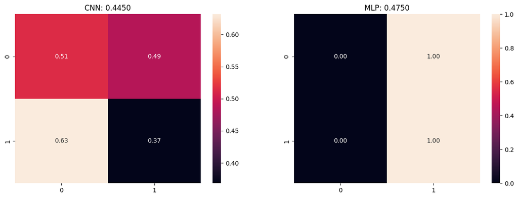

```python
compare_mlp_cnn(cnn, mlp, X_test, y_test)
```

```
Model: "sequential_16"
```

```
┏━━━━━━━━━━━━━━━━━━━━━━━━━━━━━━━━━━━━━━┳━━━━━━━━━━━━━━━━━━━━━━━━━━━━━┳━━━━━━━━━━━━━━━━━┓
┃ Layer (type)                         ┃ Output Shape                ┃         Param # ┃
┡━━━━━━━━━━━━━━━━━━━━━━━━━━━━━━━━━━━━━━╇━━━━━━━━━━━━━━━━━━━━━━━━━━━━━╇━━━━━━━━━━━━━━━━━┩
│ conv2d_12 (Conv2D)                   │ (None, 64, 64, 32)          │           2,432 │
├──────────────────────────────────────┼─────────────────────────────┼─────────────────┤
│ max_pooling2d_12 (MaxPooling2D)      │ (None, 32, 32, 32)          │               0 │
├──────────────────────────────────────┼─────────────────────────────┼─────────────────┤
│ activation_22 (Activation)           │ (None, 32, 32, 32)          │               0 │
├──────────────────────────────────────┼─────────────────────────────┼─────────────────┤
│ flatten_14 (Flatten)                 │ (None, 32768)               │               0 │
├──────────────────────────────────────┼─────────────────────────────┼─────────────────┤
│ dense_26 (Dense)                     │ (None, 2)                   │          65,538 │
├──────────────────────────────────────┼─────────────────────────────┼─────────────────┤
│ activation_23 (Activation)           │ (None, 2)                   │               0 │
└──────────────────────────────────────┴─────────────────────────────┴─────────────────┘
```

```
 Total params: 67,970 (265.51 KB)
```

```
 Trainable params: 67,970 (265.51 KB)
```

```
 Non-trainable params: 0 (0.00 B)
```

```
None
18/18 ━━━━━━━━━━━━━━━━━━━━ 4s 134ms/step - accuracy: 0.4751 - loss: 1.8201 - val_accuracy: 0.5292 - val_loss: 0.7643
18/18 ━━━━━━━━━━━━━━━━━━━━ 2s 7ms/step - accuracy: 0.5167 - loss: 0.7099 - val_accuracy: 0.5042 - val_loss: 0.6935
18/18 ━━━━━━━━━━━━━━━━━━━━ 0s 6ms/step - accuracy: 0.6726 - loss: 0.6883 - val_accuracy: 0.4625 - val_loss: 0.6938
18/18 ━━━━━━━━━━━━━━━━━━━━ 0s 6ms/step - accuracy: 0.6999 - loss: 0.6881 - val_accuracy: 0.4750 - val_loss: 0.6934
18/18 ━━━━━━━━━━━━━━━━━━━━ 0s 6ms/step - accuracy: 0.7498 - loss: 0.6821 - val_accuracy: 0.5208 - val_loss: 0.6893
18/18 ━━━━━━━━━━━━━━━━━━━━ 0s 9ms/step - accuracy: 0.6580 - loss: 0.6592 - val_accuracy: 0.5292 - val_loss: 0.6918
18/18 ━━━━━━━━━━━━━━━━━━━━ 0s 6ms/step - accuracy: 0.6178 - loss: 0.6292 - val_accuracy: 0.5125 - val_loss: 0.6912
18/18 ━━━━━━━━━━━━━━━━━━━━ 0s 6ms/step - accuracy: 0.9037 - loss: 0.5745 - val_accuracy: 0.4708 - val_loss: 0.7615
18/18 ━━━━━━━━━━━━━━━━━━━━ 0s 6ms/step - accuracy: 0.6991 - loss: 0.5500 - val_accuracy: 0.5333 - val_loss: 0.6968
18/18 ━━━━━━━━━━━━━━━━━━━━ 0s 6ms/step - accuracy: 0.8006 - loss: 0.4851 - val_accuracy: 0.5417 - val_loss: 0.6934
18/18 ━━━━━━━━━━━━━━━━━━━━ 0s 6ms/step - accuracy: 0.9313 - loss: 0.4286 - val_accuracy: 0.5542 - val_loss: 0.6868
18/18 ━━━━━━━━━━━━━━━━━━━━ 0s 6ms/step - accuracy: 0.9881 - loss: 0.3589 - val_accuracy: 0.5208 - val_loss: 0.6935
18/18 ━━━━━━━━━━━━━━━━━━━━ 0s 9ms/step - accuracy: 0.9914 - loss: 0.3031 - val_accuracy: 0.5250 - val_loss: 0.7215
18/18 ━━━━━━━━━━━━━━━━━━━━ 0s 7ms/step - accuracy: 0.9993 - loss: 0.2496 - val_accuracy: 0.5500 - val_loss: 0.6990
18/18 ━━━━━━━━━━━━━━━━━━━━ 0s 6ms/step - accuracy: 1.0000 - loss: 0.1955 - val_accuracy: 0.5333 - val_loss: 0.7043
18/18 ━━━━━━━━━━━━━━━━━━━━ 0s 6ms/step - accuracy: 1.0000 - loss: 0.1472 - val_accuracy: 0.5458 - val_loss: 0.7139
18/18 ━━━━━━━━━━━━━━━━━━━━ 0s 6ms/step - accuracy: 1.0000 - loss: 0.1130 - val_accuracy: 0.5583 - val_loss: 0.7215
18/18 ━━━━━━━━━━━━━━━━━━━━ 0s 6ms/step - accuracy: 1.0000 - loss: 0.0851 - val_accuracy: 0.5458 - val_loss: 0.7302
18/18 ━━━━━━━━━━━━━━━━━━━━ 0s 7ms/step - accuracy: 1.0000 - loss: 0.0682 - val_accuracy: 0.5083 - val_loss: 0.7662
18/18 ━━━━━━━━━━━━━━━━━━━━ 0s 6ms/step - accuracy: 1.0000 - loss: 0.0608 - val_accuracy: 0.5458 - val_loss: 0.9430
18/18 ━━━━━━━━━━━━━━━━━━━━ 0s 6ms/step - accuracy: 1.0000 - loss: 0.0692 - val_accuracy: 0.5167 - val_loss: 0.7442
18/18 ━━━━━━━━━━━━━━━━━━━━ 0s 6ms/step - accuracy: 1.0000 - loss: 0.0555 - val_accuracy: 0.5417 - val_loss: 0.9157
18/18 ━━━━━━━━━━━━━━━━━━━━ 0s 6ms/step - accuracy: 1.0000 - loss: 0.0674 - val_accuracy: 0.5292 - val_loss: 1.5148
18/18 ━━━━━━━━━━━━━━━━━━━━ 0s 6ms/step - accuracy: 0.9883 - loss: 0.1230 - val_accuracy: 0.5292 - val_loss: 1.3664
18/18 ━━━━━━━━━━━━━━━━━━━━ 0s 6ms/step - accuracy: 0.9966 - loss: 0.1010 - val_accuracy: 0.5375 - val_loss: 1.0039
18/18 ━━━━━━━━━━━━━━━━━━━━ 0s 9ms/step - accuracy: 1.0000 - loss: 0.0442 - val_accuracy: 0.5375 - val_loss: 1.0822
18/18 ━━━━━━━━━━━━━━━━━━━━ 0s 6ms/step - accuracy: 1.0000 - loss: 0.0347 - val_accuracy: 0.5375 - val_loss: 1.1446
18/18 ━━━━━━━━━━━━━━━━━━━━ 0s 6ms/step - accuracy: 1.0000 - loss: 0.0335 - val_accuracy: 0.5333 - val_loss: 1.2623
18/18 ━━━━━━━━━━━━━━━━━━━━ 0s 6ms/step - accuracy: 1.0000 - loss: 0.0451 - val_accuracy: 0.5292 - val_loss: 1.3678
18/18 ━━━━━━━━━━━━━━━━━━━━ 0s 6ms/step - accuracy: 1.0000 - loss: 0.0707 - val_accuracy: 0.5292 - val_loss: 1.3026
18/18 ━━━━━━━━━━━━━━━━━━━━ 0s 6ms/step - accuracy: 1.0000 - loss: 0.1208 - val_accuracy: 0.5292 - val_loss: 1.4623
18/18 ━━━━━━━━━━━━━━━━━━━━ 0s 7ms/step - accuracy: 1.0000 - loss: 0.0529 - val_accuracy: 0.5333 - val_loss: 1.2591
18/18 ━━━━━━━━━━━━━━━━━━━━ 0s 6ms/step - accuracy: 1.0000 - loss: 0.0257 - val_accuracy: 0.5417 - val_loss: 1.2321
18/18 ━━━━━━━━━━━━━━━━━━━━ 0s 7ms/step - accuracy: 1.0000 - loss: 0.0227 - val_accuracy: 0.5375 - val_loss: 1.2657
18/18 ━━━━━━━━━━━━━━━━━━━━ 0s 6ms/step - accuracy: 1.0000 - loss: 0.0272 - val_accuracy: 0.5292 - val_loss: 1.4210
18/18 ━━━━━━━━━━━━━━━━━━━━ 0s 6ms/step - accuracy: 1.0000 - loss: 0.0538 - val_accuracy: 0.5375 - val_loss: 1.0010
18/18 ━━━━━━━━━━━━━━━━━━━━ 0s 6ms/step - accuracy: 1.0000 - loss: 0.0580 - val_accuracy: 0.5292 - val_loss: 1.2847
18/18 ━━━━━━━━━━━━━━━━━━━━ 0s 7ms/step - accuracy: 1.0000 - loss: 0.1145 - val_accuracy: 0.5292 - val_loss: 1.3689
18/18 ━━━━━━━━━━━━━━━━━━━━ 0s 7ms/step - accuracy: 1.0000 - loss: 0.0360 - val_accuracy: 0.5333 - val_loss: 1.4608
```

[output cut: 50 more lines]

```
18/18 ━━━━━━━━━━━━━━━━━━━━ 0s 6ms/step - accuracy: 1.0000 - loss: 0.0017 - val_accuracy: 0.5333 - val_loss: 1.1057
18/18 ━━━━━━━━━━━━━━━━━━━━ 0s 6ms/step - accuracy: 1.0000 - loss: 0.0016 - val_accuracy: 0.5333 - val_loss: 1.1103
18/18 ━━━━━━━━━━━━━━━━━━━━ 0s 6ms/step - accuracy: 1.0000 - loss: 0.0015 - val_accuracy: 0.5333 - val_loss: 1.1145
18/18 ━━━━━━━━━━━━━━━━━━━━ 0s 6ms/step - accuracy: 1.0000 - loss: 0.0014 - val_accuracy: 0.5333 - val_loss: 1.1184
18/18 ━━━━━━━━━━━━━━━━━━━━ 0s 6ms/step - accuracy: 1.0000 - loss: 0.0014 - val_accuracy: 0.5333 - val_loss: 1.1216
18/18 ━━━━━━━━━━━━━━━━━━━━ 0s 6ms/step - accuracy: 1.0000 - loss: 0.0013 - val_accuracy: 0.5333 - val_loss: 1.1250
18/18 ━━━━━━━━━━━━━━━━━━━━ 0s 7ms/step - accuracy: 1.0000 - loss: 0.0012 - val_accuracy: 0.5375 - val_loss: 1.1281
18/18 ━━━━━━━━━━━━━━━━━━━━ 0s 7ms/step - accuracy: 1.0000 - loss: 0.0012 - val_accuracy: 0.5375 - val_loss: 1.1308
18/18 ━━━━━━━━━━━━━━━━━━━━ 0s 6ms/step - accuracy: 1.0000 - loss: 0.0011 - val_accuracy: 0.5375 - val_loss: 1.1337
18/18 ━━━━━━━━━━━━━━━━━━━━ 0s 6ms/step - accuracy: 1.0000 - loss: 0.0011 - val_accuracy: 0.5375 - val_loss: 1.1365
18/18 ━━━━━━━━━━━━━━━━━━━━ 0s 6ms/step - accuracy: 1.0000 - loss: 0.0010 - val_accuracy: 0.5417 - val_loss: 1.1395
7/7 ━━━━━━━━━━━━━━━━━━━━ 0s 26ms/step
Recall: 0.54
7/7 ━━━━━━━━━━━━━━━━━━━━ 0s 2ms/step
7/7 ━━━━━━━━━━━━━━━━━━━━ 0s 2ms/step
```

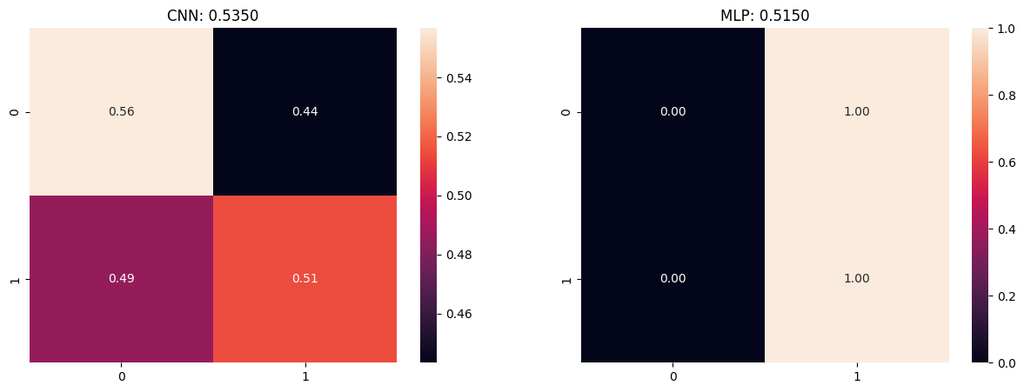

```python
#Second CNN Layer

X = np.random.rand(1000, 64, 64, 3)
y = np.random.randint(0, 2, size=(1000,))  # Binary classification (0 or 1)
NUM_CLASSES = 2

# Initialize CNN
cnn2 = Sequential()
cnn2.add(Conv2D(filters=32, kernel_size=(5, 5), padding='same', input_shape=(64, 64, 3)))
cnn2.add(MaxPooling2D(pool_size=(2, 2)))
cnn2.add(Activation('relu'))
cnn2.add(Flatten())
cnn2.add(Dense(NUM_CLASSES))
cnn2.add(Activation('softmax'))

# Compile the model
cnn2.compile(loss='sparse_categorical_crossentropy',
            optimizer='adam',
            metrics=['accuracy'])

# Print model summary
print(cnn2.summary())

# Plot the model architecture
plot_model(
    cnn, to_file='model.png', show_shapes=True, show_layer_names=True,
    rankdir='LR', expand_nested=False, dpi=96
)

# Use ShuffleSplit to split the dataset
ss = ShuffleSplit(n_splits=1, test_size=0.2, random_state=42)

for train_index, test_index in ss.split(X):
    X_train, X_test = X[train_index], X[test_index]
    y_train, y_test = y[train_index], y[test_index]

# Train the CNN
cnn2.fit(X_train, y_train, epochs=100, batch_size=32, validation_split=0.3)

# Evaluate on test set
y_pred = cnn2.predict(X_test)
y_pred_classes = np.argmax(y_pred, axis=1)  # Get the predicted class indices

# Calculate Recall
recall = recall_score(y_test, y_pred_classes, average='weighted')  # Weighted Recall
print(f"Recall: {recall:.2f}")

compare_mlp_cnn(cnn2, mlp, X_test, y_test)
```

```
Model: "sequential_17"
```

```
┏━━━━━━━━━━━━━━━━━━━━━━━━━━━━━━━━━━━━━━┳━━━━━━━━━━━━━━━━━━━━━━━━━━━━━┳━━━━━━━━━━━━━━━━━┓
┃ Layer (type)                         ┃ Output Shape                ┃         Param # ┃
┡━━━━━━━━━━━━━━━━━━━━━━━━━━━━━━━━━━━━━━╇━━━━━━━━━━━━━━━━━━━━━━━━━━━━━╇━━━━━━━━━━━━━━━━━┩
│ conv2d_13 (Conv2D)                   │ (None, 64, 64, 128)         │           1,664 │
├──────────────────────────────────────┼─────────────────────────────┼─────────────────┤
│ max_pooling2d_13 (MaxPooling2D)      │ (None, 12, 12, 128)         │               0 │
├──────────────────────────────────────┼─────────────────────────────┼─────────────────┤
│ activation_24 (Activation)           │ (None, 12, 12, 128)         │               0 │
├──────────────────────────────────────┼─────────────────────────────┼─────────────────┤
│ flatten_15 (Flatten)                 │ (None, 18432)               │               0 │
├──────────────────────────────────────┼─────────────────────────────┼─────────────────┤
│ dense_27 (Dense)                     │ (None, 2)                   │          36,866 │
├──────────────────────────────────────┼─────────────────────────────┼─────────────────┤
│ activation_25 (Activation)           │ (None, 2)                   │               0 │
└──────────────────────────────────────┴─────────────────────────────┴─────────────────┘
```

```
 Total params: 38,530 (150.51 KB)
```

```
 Trainable params: 38,530 (150.51 KB)
```

```
 Non-trainable params: 0 (0.00 B)
```

```
None
20/20 ━━━━━━━━━━━━━━━━━━━━ 4s 95ms/step - accuracy: 0.5363 - loss: 0.9806 - val_accuracy: 0.5500 - val_loss: 0.7294
20/20 ━━━━━━━━━━━━━━━━━━━━ 0s 9ms/step - accuracy: 0.5260 - loss: 0.7220 - val_accuracy: 0.4500 - val_loss: 0.7240
20/20 ━━━━━━━━━━━━━━━━━━━━ 0s 9ms/step - accuracy: 0.5662 - loss: 0.6814 - val_accuracy: 0.5500 - val_loss: 0.6887
20/20 ━━━━━━━━━━━━━━━━━━━━ 0s 7ms/step - accuracy: 0.5958 - loss: 0.6564 - val_accuracy: 0.4688 - val_loss: 0.6976
20/20 ━━━━━━━━━━━━━━━━━━━━ 0s 7ms/step - accuracy: 0.6988 - loss: 0.6281 - val_accuracy: 0.4812 - val_loss: 0.6963
20/20 ━━━━━━━━━━━━━━━━━━━━ 0s 8ms/step - accuracy: 0.7601 - loss: 0.5947 - val_accuracy: 0.4812 - val_loss: 0.6965
20/20 ━━━━━━━━━━━━━━━━━━━━ 0s 7ms/step - accuracy: 0.8174 - loss: 0.5590 - val_accuracy: 0.4750 - val_loss: 0.6978
20/20 ━━━━━━━━━━━━━━━━━━━━ 0s 7ms/step - accuracy: 0.8884 - loss: 0.5196 - val_accuracy: 0.4500 - val_loss: 0.6991
20/20 ━━━━━━━━━━━━━━━━━━━━ 0s 7ms/step - accuracy: 0.9376 - loss: 0.4784 - val_accuracy: 0.4688 - val_loss: 0.6996
20/20 ━━━━━━━━━━━━━━━━━━━━ 0s 8ms/step - accuracy: 0.9729 - loss: 0.4361 - val_accuracy: 0.4750 - val_loss: 0.6990
20/20 ━━━━━━━━━━━━━━━━━━━━ 0s 7ms/step - accuracy: 0.9828 - loss: 0.3940 - val_accuracy: 0.5312 - val_loss: 0.6979
20/20 ━━━━━━━━━━━━━━━━━━━━ 0s 7ms/step - accuracy: 0.9980 - loss: 0.3524 - val_accuracy: 0.5625 - val_loss: 0.6984
20/20 ━━━━━━━━━━━━━━━━━━━━ 0s 7ms/step - accuracy: 1.0000 - loss: 0.3123 - val_accuracy: 0.5750 - val_loss: 0.7015
20/20 ━━━━━━━━━━━━━━━━━━━━ 0s 7ms/step - accuracy: 1.0000 - loss: 0.2751 - val_accuracy: 0.5750 - val_loss: 0.7054
20/20 ━━━━━━━━━━━━━━━━━━━━ 0s 6ms/step - accuracy: 1.0000 - loss: 0.2416 - val_accuracy: 0.5750 - val_loss: 0.7102
20/20 ━━━━━━━━━━━━━━━━━━━━ 0s 6ms/step - accuracy: 1.0000 - loss: 0.2117 - val_accuracy: 0.5750 - val_loss: 0.7153
20/20 ━━━━━━━━━━━━━━━━━━━━ 0s 6ms/step - accuracy: 1.0000 - loss: 0.1852 - val_accuracy: 0.5688 - val_loss: 0.7209
20/20 ━━━━━━━━━━━━━━━━━━━━ 0s 6ms/step - accuracy: 1.0000 - loss: 0.1621 - val_accuracy: 0.5625 - val_loss: 0.7267
20/20 ━━━━━━━━━━━━━━━━━━━━ 0s 6ms/step - accuracy: 1.0000 - loss: 0.1422 - val_accuracy: 0.5500 - val_loss: 0.7330
20/20 ━━━━━━━━━━━━━━━━━━━━ 0s 7ms/step - accuracy: 1.0000 - loss: 0.1252 - val_accuracy: 0.5375 - val_loss: 0.7399
20/20 ━━━━━━━━━━━━━━━━━━━━ 0s 6ms/step - accuracy: 1.0000 - loss: 0.1109 - val_accuracy: 0.5188 - val_loss: 0.7473
20/20 ━━━━━━━━━━━━━━━━━━━━ 0s 6ms/step - accuracy: 1.0000 - loss: 0.0989 - val_accuracy: 0.5125 - val_loss: 0.7563
20/20 ━━━━━━━━━━━━━━━━━━━━ 0s 6ms/step - accuracy: 1.0000 - loss: 0.0893 - val_accuracy: 0.5125 - val_loss: 0.7701
20/20 ━━━━━━━━━━━━━━━━━━━━ 0s 6ms/step - accuracy: 1.0000 - loss: 0.0826 - val_accuracy: 0.4688 - val_loss: 0.8039
20/20 ━━━━━━━━━━━━━━━━━━━━ 0s 6ms/step - accuracy: 1.0000 - loss: 0.0813 - val_accuracy: 0.4375 - val_loss: 0.9309
20/20 ━━━━━━━━━━━━━━━━━━━━ 0s 7ms/step - accuracy: 1.0000 - loss: 0.0981 - val_accuracy: 0.4625 - val_loss: 1.1115
20/20 ━━━━━━━━━━━━━━━━━━━━ 0s 6ms/step - accuracy: 0.9909 - loss: 0.1515 - val_accuracy: 0.5750 - val_loss: 0.7922
20/20 ━━━━━━━━━━━━━━━━━━━━ 0s 6ms/step - accuracy: 1.0000 - loss: 0.0812 - val_accuracy: 0.5500 - val_loss: 0.7801
20/20 ━━━━━━━━━━━━━━━━━━━━ 0s 6ms/step - accuracy: 1.0000 - loss: 0.0546 - val_accuracy: 0.5437 - val_loss: 0.7896
20/20 ━━━━━━━━━━━━━━━━━━━━ 0s 6ms/step - accuracy: 1.0000 - loss: 0.0494 - val_accuracy: 0.5625 - val_loss: 0.7955
20/20 ━━━━━━━━━━━━━━━━━━━━ 0s 6ms/step - accuracy: 1.0000 - loss: 0.0446 - val_accuracy: 0.5625 - val_loss: 0.8063
20/20 ━━━━━━━━━━━━━━━━━━━━ 0s 6ms/step - accuracy: 1.0000 - loss: 0.0384 - val_accuracy: 0.5688 - val_loss: 0.8082
20/20 ━━━━━━━━━━━━━━━━━━━━ 0s 6ms/step - accuracy: 1.0000 - loss: 0.0342 - val_accuracy: 0.5562 - val_loss: 0.8116
20/20 ━━━━━━━━━━━━━━━━━━━━ 0s 7ms/step - accuracy: 1.0000 - loss: 0.0316 - val_accuracy: 0.5688 - val_loss: 0.8166
20/20 ━━━━━━━━━━━━━━━━━━━━ 0s 6ms/step - accuracy: 1.0000 - loss: 0.0292 - val_accuracy: 0.5562 - val_loss: 0.8210
20/20 ━━━━━━━━━━━━━━━━━━━━ 0s 6ms/step - accuracy: 1.0000 - loss: 0.0271 - val_accuracy: 0.5500 - val_loss: 0.8251
20/20 ━━━━━━━━━━━━━━━━━━━━ 0s 6ms/step - accuracy: 1.0000 - loss: 0.0253 - val_accuracy: 0.5437 - val_loss: 0.8291
20/20 ━━━━━━━━━━━━━━━━━━━━ 0s 7ms/step - accuracy: 1.0000 - loss: 0.0237 - val_accuracy: 0.5437 - val_loss: 0.8331
20/20 ━━━━━━━━━━━━━━━━━━━━ 0s 6ms/step - accuracy: 1.0000 - loss: 0.0223 - val_accuracy: 0.5375 - val_loss: 0.8369
```

[output cut: 50 more lines]

```
20/20 ━━━━━━━━━━━━━━━━━━━━ 0s 7ms/step - accuracy: 1.0000 - loss: 0.0018 - val_accuracy: 0.5125 - val_loss: 1.0384
20/20 ━━━━━━━━━━━━━━━━━━━━ 0s 6ms/step - accuracy: 1.0000 - loss: 0.0018 - val_accuracy: 0.5125 - val_loss: 1.0419
20/20 ━━━━━━━━━━━━━━━━━━━━ 0s 7ms/step - accuracy: 1.0000 - loss: 0.0017 - val_accuracy: 0.5125 - val_loss: 1.0451
20/20 ━━━━━━━━━━━━━━━━━━━━ 0s 6ms/step - accuracy: 1.0000 - loss: 0.0016 - val_accuracy: 0.5125 - val_loss: 1.0479
20/20 ━━━━━━━━━━━━━━━━━━━━ 0s 7ms/step - accuracy: 1.0000 - loss: 0.0016 - val_accuracy: 0.5125 - val_loss: 1.0504
20/20 ━━━━━━━━━━━━━━━━━━━━ 0s 6ms/step - accuracy: 1.0000 - loss: 0.0015 - val_accuracy: 0.5125 - val_loss: 1.0528
20/20 ━━━━━━━━━━━━━━━━━━━━ 0s 7ms/step - accuracy: 1.0000 - loss: 0.0015 - val_accuracy: 0.5188 - val_loss: 1.0551
20/20 ━━━━━━━━━━━━━━━━━━━━ 0s 6ms/step - accuracy: 1.0000 - loss: 0.0014 - val_accuracy: 0.5188 - val_loss: 1.0573
20/20 ━━━━━━━━━━━━━━━━━━━━ 0s 7ms/step - accuracy: 1.0000 - loss: 0.0014 - val_accuracy: 0.5188 - val_loss: 1.0593
20/20 ━━━━━━━━━━━━━━━━━━━━ 0s 6ms/step - accuracy: 1.0000 - loss: 0.0014 - val_accuracy: 0.5188 - val_loss: 1.0613
20/20 ━━━━━━━━━━━━━━━━━━━━ 0s 6ms/step - accuracy: 1.0000 - loss: 0.0013 - val_accuracy: 0.5188 - val_loss: 1.0631
7/7 ━━━━━━━━━━━━━━━━━━━━ 0s 27ms/step
Recall: 0.43
7/7 ━━━━━━━━━━━━━━━━━━━━ 0s 2ms/step
7/7 ━━━━━━━━━━━━━━━━━━━━ 0s 2ms/step
```

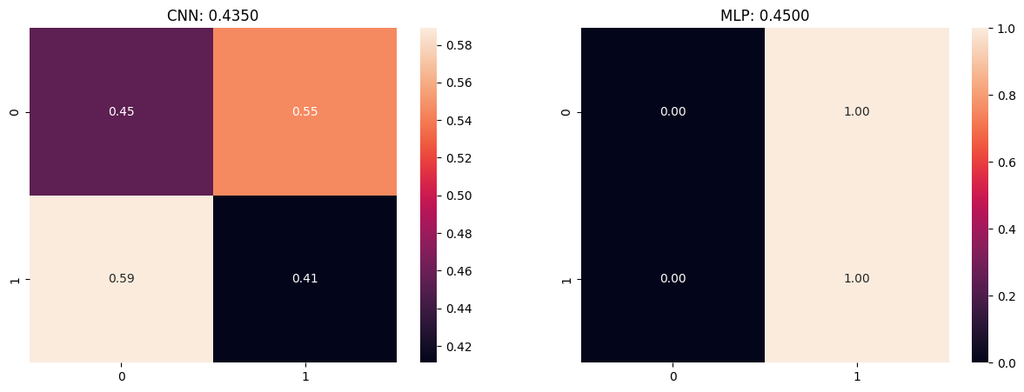

```python
#Third CNN Layer

X = np.random.rand(1000, 64, 64, 3)
y = np.random.randint(0, 2, size=(1000,))  # Binary classification (0 or 1)
NUM_CLASSES = 2

# Initialize CNN
cnn3 = Sequential()
cnn3.add(Conv2D(filters=128, kernel_size=(2, 2), padding='same', input_shape=(64, 64, 3)))
cnn3.add(MaxPooling2D(pool_size=(5, 5)))
cnn3.add(Activation('relu'))
cnn3.add(Flatten())
cnn3.add(Dense(NUM_CLASSES))
cnn3.add(Activation('softmax'))

# Compile the model
cnn3.compile(loss='sparse_categorical_crossentropy',
            optimizer='adam',
            metrics=['accuracy'])

# Print model summary
print(cnn3.summary())

# Plot the model architecture
plot_model(
    cnn, to_file='model.png', show_shapes=True, show_layer_names=True,
    rankdir='LR', expand_nested=False, dpi=96
)

# Use ShuffleSplit to split the dataset
ss = ShuffleSplit(n_splits=1, test_size=0.2, random_state=42)

for train_index, test_index in ss.split(X):
    X_train, X_test = X[train_index], X[test_index]
    y_train, y_test = y[train_index], y[test_index]

# Train the CNN
cnn3.fit(X_train, y_train, epochs=100, batch_size=32, validation_split=0.2)

# Evaluate on test set
y_pred = cnn3.predict(X_test)
y_pred_classes = np.argmax(y_pred, axis=1)  # Get the predicted class indices

# Calculate Recall
recall = recall_score(y_test, y_pred_classes, average='weighted')  # Weighted Recall
print(f"Recall: {recall:.2f}")

compare_mlp_cnn(cnn3, mlp, X_test, y_test)
```

```
Model: "sequential_18"
```

```
┏━━━━━━━━━━━━━━━━━━━━━━━━━━━━━━━━━━━━━━┳━━━━━━━━━━━━━━━━━━━━━━━━━━━━━┳━━━━━━━━━━━━━━━━━┓
┃ Layer (type)                         ┃ Output Shape                ┃         Param # ┃
┡━━━━━━━━━━━━━━━━━━━━━━━━━━━━━━━━━━━━━━╇━━━━━━━━━━━━━━━━━━━━━━━━━━━━━╇━━━━━━━━━━━━━━━━━┩
│ conv2d_14 (Conv2D)                   │ (None, 64, 64, 32)          │           2,432 │
├──────────────────────────────────────┼─────────────────────────────┼─────────────────┤
│ max_pooling2d_14 (MaxPooling2D)      │ (None, 12, 12, 32)          │               0 │
├──────────────────────────────────────┼─────────────────────────────┼─────────────────┤
│ activation_26 (Activation)           │ (None, 12, 12, 32)          │               0 │
├──────────────────────────────────────┼─────────────────────────────┼─────────────────┤
│ flatten_16 (Flatten)                 │ (None, 4608)                │               0 │
├──────────────────────────────────────┼─────────────────────────────┼─────────────────┤
│ dense_28 (Dense)                     │ (None, 2)                   │           9,218 │
├──────────────────────────────────────┼─────────────────────────────┼─────────────────┤
│ activation_27 (Activation)           │ (None, 2)                   │               0 │
└──────────────────────────────────────┴─────────────────────────────┴─────────────────┘
```

```
 Total params: 11,650 (45.51 KB)
```

```
 Trainable params: 11,650 (45.51 KB)
```

```
 Non-trainable params: 0 (0.00 B)
```

```
None
18/18 ━━━━━━━━━━━━━━━━━━━━ 4s 143ms/step - accuracy: 0.4569 - loss: 0.8044 - val_accuracy: 0.5429 - val_loss: 0.6912
18/18 ━━━━━━━━━━━━━━━━━━━━ 0s 8ms/step - accuracy: 0.4793 - loss: 0.6963 - val_accuracy: 0.4429 - val_loss: 0.7069
18/18 ━━━━━━━━━━━━━━━━━━━━ 0s 8ms/step - accuracy: 0.5662 - loss: 0.6820 - val_accuracy: 0.5286 - val_loss: 0.6970
18/18 ━━━━━━━━━━━━━━━━━━━━ 0s 6ms/step - accuracy: 0.6045 - loss: 0.6749 - val_accuracy: 0.4429 - val_loss: 0.7023
18/18 ━━━━━━━━━━━━━━━━━━━━ 0s 6ms/step - accuracy: 0.6659 - loss: 0.6590 - val_accuracy: 0.4286 - val_loss: 0.7105
18/18 ━━━━━━━━━━━━━━━━━━━━ 0s 6ms/step - accuracy: 0.7097 - loss: 0.6390 - val_accuracy: 0.4500 - val_loss: 0.7129
18/18 ━━━━━━━━━━━━━━━━━━━━ 0s 6ms/step - accuracy: 0.8093 - loss: 0.6161 - val_accuracy: 0.4429 - val_loss: 0.7117
18/18 ━━━━━━━━━━━━━━━━━━━━ 0s 6ms/step - accuracy: 0.9172 - loss: 0.5904 - val_accuracy: 0.4500 - val_loss: 0.7073
18/18 ━━━━━━━━━━━━━━━━━━━━ 0s 6ms/step - accuracy: 0.9633 - loss: 0.5647 - val_accuracy: 0.4429 - val_loss: 0.7099
18/18 ━━━━━━━━━━━━━━━━━━━━ 0s 5ms/step - accuracy: 0.9738 - loss: 0.5366 - val_accuracy: 0.4571 - val_loss: 0.7111
18/18 ━━━━━━━━━━━━━━━━━━━━ 0s 6ms/step - accuracy: 0.9752 - loss: 0.5084 - val_accuracy: 0.4571 - val_loss: 0.7140
18/18 ━━━━━━━━━━━━━━━━━━━━ 0s 5ms/step - accuracy: 0.9815 - loss: 0.4793 - val_accuracy: 0.4429 - val_loss: 0.7163
18/18 ━━━━━━━━━━━━━━━━━━━━ 0s 5ms/step - accuracy: 0.9918 - loss: 0.4496 - val_accuracy: 0.4286 - val_loss: 0.7171
18/18 ━━━━━━━━━━━━━━━━━━━━ 0s 7ms/step - accuracy: 0.9981 - loss: 0.4198 - val_accuracy: 0.4357 - val_loss: 0.7195
18/18 ━━━━━━━━━━━━━━━━━━━━ 0s 6ms/step - accuracy: 0.9988 - loss: 0.3899 - val_accuracy: 0.4357 - val_loss: 0.7209
18/18 ━━━━━━━━━━━━━━━━━━━━ 0s 5ms/step - accuracy: 0.9988 - loss: 0.3605 - val_accuracy: 0.4286 - val_loss: 0.7216
18/18 ━━━━━━━━━━━━━━━━━━━━ 0s 5ms/step - accuracy: 1.0000 - loss: 0.3319 - val_accuracy: 0.4357 - val_loss: 0.7239
18/18 ━━━━━━━━━━━━━━━━━━━━ 0s 6ms/step - accuracy: 1.0000 - loss: 0.3046 - val_accuracy: 0.4214 - val_loss: 0.7264
18/18 ━━━━━━━━━━━━━━━━━━━━ 0s 5ms/step - accuracy: 1.0000 - loss: 0.2786 - val_accuracy: 0.4429 - val_loss: 0.7298
18/18 ━━━━━━━━━━━━━━━━━━━━ 0s 6ms/step - accuracy: 1.0000 - loss: 0.2541 - val_accuracy: 0.4571 - val_loss: 0.7348
18/18 ━━━━━━━━━━━━━━━━━━━━ 0s 5ms/step - accuracy: 1.0000 - loss: 0.2312 - val_accuracy: 0.4571 - val_loss: 0.7398
18/18 ━━━━━━━━━━━━━━━━━━━━ 0s 6ms/step - accuracy: 1.0000 - loss: 0.2101 - val_accuracy: 0.4714 - val_loss: 0.7439
18/18 ━━━━━━━━━━━━━━━━━━━━ 0s 6ms/step - accuracy: 1.0000 - loss: 0.1907 - val_accuracy: 0.4714 - val_loss: 0.7471
18/18 ━━━━━━━━━━━━━━━━━━━━ 0s 6ms/step - accuracy: 1.0000 - loss: 0.1729 - val_accuracy: 0.4714 - val_loss: 0.7513
18/18 ━━━━━━━━━━━━━━━━━━━━ 0s 6ms/step - accuracy: 1.0000 - loss: 0.1567 - val_accuracy: 0.4786 - val_loss: 0.7550
18/18 ━━━━━━━━━━━━━━━━━━━━ 0s 6ms/step - accuracy: 1.0000 - loss: 0.1419 - val_accuracy: 0.4786 - val_loss: 0.7580
18/18 ━━━━━━━━━━━━━━━━━━━━ 0s 6ms/step - accuracy: 1.0000 - loss: 0.1280 - val_accuracy: 0.5000 - val_loss: 0.7598
18/18 ━━━━━━━━━━━━━━━━━━━━ 0s 6ms/step - accuracy: 1.0000 - loss: 0.1157 - val_accuracy: 0.5071 - val_loss: 0.7613
18/18 ━━━━━━━━━━━━━━━━━━━━ 0s 6ms/step - accuracy: 1.0000 - loss: 0.1048 - val_accuracy: 0.5143 - val_loss: 0.7625
18/18 ━━━━━━━━━━━━━━━━━━━━ 0s 6ms/step - accuracy: 1.0000 - loss: 0.0953 - val_accuracy: 0.5071 - val_loss: 0.7602
18/18 ━━━━━━━━━━━━━━━━━━━━ 0s 6ms/step - accuracy: 1.0000 - loss: 0.0873 - val_accuracy: 0.5071 - val_loss: 0.7551
18/18 ━━━━━━━━━━━━━━━━━━━━ 0s 6ms/step - accuracy: 1.0000 - loss: 0.0809 - val_accuracy: 0.5357 - val_loss: 0.7488
18/18 ━━━━━━━━━━━━━━━━━━━━ 0s 5ms/step - accuracy: 1.0000 - loss: 0.0773 - val_accuracy: 0.5929 - val_loss: 0.7565
18/18 ━━━━━━━━━━━━━━━━━━━━ 0s 7ms/step - accuracy: 1.0000 - loss: 0.0785 - val_accuracy: 0.5643 - val_loss: 0.7572
18/18 ━━━━━━━━━━━━━━━━━━━━ 0s 6ms/step - accuracy: 1.0000 - loss: 0.0746 - val_accuracy: 0.4643 - val_loss: 0.8892
18/18 ━━━━━━━━━━━━━━━━━━━━ 0s 7ms/step - accuracy: 1.0000 - loss: 0.0602 - val_accuracy: 0.4714 - val_loss: 0.8394
18/18 ━━━━━━━━━━━━━━━━━━━━ 0s 5ms/step - accuracy: 1.0000 - loss: 0.0516 - val_accuracy: 0.5000 - val_loss: 0.8215
18/18 ━━━━━━━━━━━━━━━━━━━━ 0s 5ms/step - accuracy: 1.0000 - loss: 0.0472 - val_accuracy: 0.4786 - val_loss: 0.8468
18/18 ━━━━━━━━━━━━━━━━━━━━ 0s 5ms/step - accuracy: 1.0000 - loss: 0.0437 - val_accuracy: 0.4571 - val_loss: 0.8642
```

[output cut: 50 more lines]

```
18/18 ━━━━━━━━━━━━━━━━━━━━ 0s 5ms/step - accuracy: 1.0000 - loss: 0.0039 - val_accuracy: 0.4714 - val_loss: 0.9502
18/18 ━━━━━━━━━━━━━━━━━━━━ 0s 5ms/step - accuracy: 1.0000 - loss: 0.0038 - val_accuracy: 0.4786 - val_loss: 0.9519
18/18 ━━━━━━━━━━━━━━━━━━━━ 0s 6ms/step - accuracy: 1.0000 - loss: 0.0037 - val_accuracy: 0.4786 - val_loss: 0.9536
18/18 ━━━━━━━━━━━━━━━━━━━━ 0s 7ms/step - accuracy: 1.0000 - loss: 0.0036 - val_accuracy: 0.4857 - val_loss: 0.9553
18/18 ━━━━━━━━━━━━━━━━━━━━ 0s 6ms/step - accuracy: 1.0000 - loss: 0.0035 - val_accuracy: 0.4857 - val_loss: 0.9570
18/18 ━━━━━━━━━━━━━━━━━━━━ 0s 5ms/step - accuracy: 1.0000 - loss: 0.0034 - val_accuracy: 0.4929 - val_loss: 0.9586
18/18 ━━━━━━━━━━━━━━━━━━━━ 0s 6ms/step - accuracy: 1.0000 - loss: 0.0034 - val_accuracy: 0.4929 - val_loss: 0.9603
18/18 ━━━━━━━━━━━━━━━━━━━━ 0s 5ms/step - accuracy: 1.0000 - loss: 0.0033 - val_accuracy: 0.4929 - val_loss: 0.9619
18/18 ━━━━━━━━━━━━━━━━━━━━ 0s 6ms/step - accuracy: 1.0000 - loss: 0.0032 - val_accuracy: 0.4929 - val_loss: 0.9635
18/18 ━━━━━━━━━━━━━━━━━━━━ 0s 7ms/step - accuracy: 1.0000 - loss: 0.0031 - val_accuracy: 0.4929 - val_loss: 0.9652
18/18 ━━━━━━━━━━━━━━━━━━━━ 0s 5ms/step - accuracy: 1.0000 - loss: 0.0031 - val_accuracy: 0.4929 - val_loss: 0.9667
10/10 ━━━━━━━━━━━━━━━━━━━━ 0s 19ms/step
Recall: 0.52
10/10 ━━━━━━━━━━━━━━━━━━━━ 0s 2ms/step
10/10 ━━━━━━━━━━━━━━━━━━━━ 0s 11ms/step
```

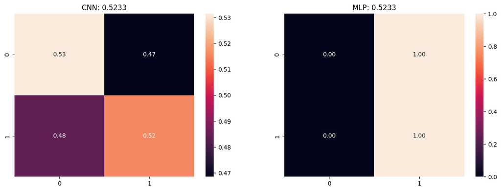

```python
#Fourth CNN Layer
X = np.random.rand(1000, 64, 64, 3)
y = np.random.randint(0, 2, size=(1000,))  # Binary classification (0 or 1)
NUM_CLASSES = 2

# Initialize CNN
cnn4 = Sequential()
cnn4.add(Conv2D(filters=32, kernel_size=(5, 5), padding='same', input_shape=(64, 64, 3)))
cnn4.add(MaxPooling2D(pool_size=(5, 5)))
cnn4.add(Activation('relu'))
cnn4.add(Flatten())
cnn4.add(Dense(NUM_CLASSES))
cnn4.add(Activation('softmax'))

# Compile the model
cnn4.compile(loss='sparse_categorical_crossentropy',
            optimizer='adam',
            metrics=['accuracy'])

# Print model summary
print(cnn4.summary())

# Plot the model architecture
plot_model(
    cnn, to_file='model.png', show_shapes=True, show_layer_names=True,
    rankdir='LR', expand_nested=False, dpi=96
)

# Use ShuffleSplit to split the dataset
ss = ShuffleSplit(n_splits=1, test_size=0.3, random_state=42)

for train_index, test_index in ss.split(X):
    X_train, X_test = X[train_index], X[test_index]
    y_train, y_test = y[train_index], y[test_index]

# Train the CNN
cnn4.fit(X_train, y_train, epochs=100, batch_size=32, validation_split=0.2)

# Evaluate on test set
y_pred = cnn4.predict(X_test)
y_pred_classes = np.argmax(y_pred, axis=1)  # Get the predicted class indices

# Calculate Recall
recall = recall_score(y_test, y_pred_classes, average='weighted')  # Weighted Recall
print(f"Recall: {recall:.2f}")

compare_mlp_cnn(cnn4, mlp, X_test, y_test)
```